```python
# run short javascript/jquery script I wrote to show/hide code blocks
from IPython.display import HTML
HTML('athospy/show_hide_code.html')
```

# Exercise classification using Athos EMG-sensor garments

The ability to quantify an individual's level of physical activity is a major challenge in personal health and fitness. Although heart rate monitors and step counters have existed for decades, devices and data systems for measuring how well an athlete's muscles and joints function are still needed.

[ATHOS](http://liveathos.com/) is making a significant step towards filling this need, by providing smart garments with embedded EMG (electromyography) sensors for the upper and lower extremity. These sensors measure muscle activity in real time during physical exercise, enabling quantification of biomechanical metrics such as intensity, cadence, and timing.

In this blog post I collaborate with ATHOS to investigate the question:

> *Can muscle activity data from Athos EMG sensors help keep track of what exercises a user is performing during his or her workouts?*

If so, Athos technology could potentially eliminate the need for users to manually log their own workouts--opening the door to a wide range of services including exercise-specific workout statistics and personalized training recommendations.

- First, I'll clean up the raw data and parse out any useful meta-data from file names, folder names, and `README` contents.
- Then, I'll do some exploratory analysis to identify quantitative features that could be used to explain differences in muscle activity between exercises.
- Finally, I'll develop and test some models for classifying exercises, and tune their parameters to optimize performance.

This post serves to document the steps I took in my analysis, and is intended for a somewhat technical reader--ideally, someone at Athos who needs to work with this data. High-level function calls and some example code is included in this post and can be shown/hidden by clicking the link at the top of this page.

```python
# import my modules and set the ipython configuration
import athospy.top_fcns as my         # high level functions
import athospy.visualization as viz   # plotting

# python packages used in examples
import numpy            # calculations
import pandas           # manipulating tables
import re               # file name parsing using regular expressions
import difflib          # fuzzy string matching of manually entered labels

# ipython "magic"
%matplotlib inline
%load_ext autoreload
%autoreload 2

viz.set_styles()       # set mpl and parameters
```

## Data preparation

Usually, the first step in executing a data science project is data preparation, or "cleaning". This process might involve reorganization or reformatting of data files, identification and filtering of 'bad' data, and handling of special cases.

The data I received from Athos was not unlike the kind of data one might find in a typical biomechanics lab. Upon initial inspection it appeared to have been collected, organized, and annotated manually, so I knew I'd have to do a significant amount of pre-processing before embarking on analysis.

My workflow consisted of the following steps:

- parse out labels (person, exercise, leg side, other...) from data folders and CSV files
- inspect some of the data to see what we're working with
- identify experiment files with potentially corrupt data
- summarize the dataset
- select portions of the data for training/testing/validation

*My understanding is that Athos has since transitioned to a more streamlined data collection and processing pipeline. However, their older data is incredibly valuable, so they asked for my help extracting insights from it.*

##### Parsing

Data was in the form of CSV files nested under various parent directories corresponding to the type of exercise performed and the person performing the exercise. As is often the case, the directory and folders were named using different conventions, sometimes with misspellings. So my first challenge was to parse out the relevant metadata from file and folder names and generate appropriate labels.

To achieve this, I used a combination of regular expressions and fuzzy string matching to:  
1) capture the relevant tokens within folder and file names, and  
2) map those tokens to a set of known exercises and individuals, which serve as labels for the data.

Here's an example of how parsing of CSV file names using regular expressions might work for a few cases, where the captured tokens correspond to `Person`, `Exercise`, `Leg_side`, `Weight_lifted`, and `Additional_info`:

```python
# EXAMPLE:  parse labels from csv file names
for s in ['MarkSena_BBSquat45.csv             ',
          'MarkSena_ProneHamstringCurlR30_2_.csv',
          'MarkSena _ButtBlaster_L20plus45.csv']:

    labels = re.findall(r"^([a-zA-Z ]+)(?:_| _)([A-Za-z]+)_?([LR])(\d*)(.{0,4})\.csv", s)
    if not labels: labels = re.findall(r"^([a-zA-Z ]+)(?:_| _)([A-Za-z]+)_?([LR])?(\d*)(.{0,8})\.csv", s)

    print s, '\t-> ', labels
```

```
MarkSena_BBSquat45.csv              	->  [('MarkSena', 'BBSquat', '', '45', '')]
MarkSena_ProneHamstringCurlR30_2_.csv 	->  [('MarkSena', 'ProneHamstringCurl', 'R', '30', '_2_')]
MarkSena _ButtBlaster_L20plus45.csv 	->  [('MarkSena ', 'ButtBlaster', 'L', '20', 'plus45')]
```

Applying this technique to folder names and CSV file names underneath the main data directory, I obtained:

- a table for all data directories and their labels, and
- a table for all csv files and their labels (indexed by directory)

along with a record for the directories and files that could not be parsed:

```python
# create table for labeled data-folders
DATA_DIR = '../data/Research-Sessions/'
folders_labeled = my.label_folders(DATA_DIR, '../data/folders_labeled.csv')
files_labeled = my.label_csvfiles_by_folder(DATA_DIR, folders_labeled, '../data/files_labeled.csv')
```

```
Parsed 85 of 91 items. See record at "../data/folders_labeled.csv"
Parsed 2425 of 2496 items. See record at "../data/files_labeled.csv"
```

Joining these two tables on the folder id combines the labels from data-folder names and csv-file names. Here, I merged only the columns needed to identify the type of activity (`Exercise`, `Legside`, and `Resistance`) and the person performing the exercise (`Person_id`), but the other labels may be useful later. We can use this table to index into the data files (which were copied and renamed to maintain anonymity), and associate the desired labels with them.

```python
files = my.join_and_anonymize(files_labeled, folders_labeled, '../data/anonymized/')
```

```
Copied 2425 files and renamed by file_id. See "../data/anonymized/"
```

Finally, I can map manually entered exercise names to a list of known exercises I created. Fuzzy string matching using the [`difflib`](https://docs.python.org/2/library/difflib.html) package makes this processes easier.

```python
# replace exercises with known exercises from my list
# drop unmatched exercises
with open('config/exercise-list_short.txt') as f:
    exercise_list = [line.rstrip() for line in f]

files.Exercise = files.Exercise.apply(
    lambda s: my.get_best_match(s, exercise_list))
files.dropna(inplace=True)
files
```

|  | Person_id | Trial | Exercise | Legside | Resistance | Path |
| --- | --- | --- | --- | --- | --- | --- |
| 2 | 0 |  | Butt Blaster | L | 10 | ../data/anonymized/2.csv |
| 3 | 0 |  | Butt Blaster | L | 20 | ../data/anonymized/3.csv |
| 4 | 0 |  | Butt Blaster | R | 20 | ../data/anonymized/4.csv |
| 5 | 0 |  | Butt Blaster | R | 20 | ../data/anonymized/5.csv |
| 6 | 0 |  | Butt Blaster | R | 8 | ../data/anonymized/6.csv |
| 7 | 0 |  | Leg Press | L | 180 | ../data/anonymized/7.csv |
| 8 | 0 |  | Leg Press | L | 220 | ../data/anonymized/8.csv |
| 9 | 0 |  | Leg Press | L | 60 | ../data/anonymized/9.csv |
| 10 | 0 |  | Leg Press | R | 160 | ../data/anonymized/10.csv |
| 11 | 0 |  | Leg Press | R | 200 | ../data/anonymized/11.csv |
| 12 | 0 |  | Leg Press | R | 60 | ../data/anonymized/12.csv |
| 13 | 0 |  | Prone Hamstring Curl | L | 30 | ../data/anonymized/13.csv |
| 14 | 0 |  | Prone Hamstring Curl | L | 60 | ../data/anonymized/14.csv |
| 15 | 0 |  | Prone Hamstring Curl | L | 75 | ../data/anonymized/15.csv |
| 16 | 0 |  | Prone Hamstring Curl | R | 30 | ../data/anonymized/16.csv |
| 17 | 0 |  | Prone Hamstring Curl | R | 60 | ../data/anonymized/17.csv |
| 18 | 0 |  | Prone Hamstring Curl | R | 75 | ../data/anonymized/18.csv |
| 19 | 0 |  | Stairs |  |  | ../data/anonymized/19.csv |
| 20 | 0 |  | Stairs |  |  | ../data/anonymized/20.csv |
| 21 | 0 |  | Still |  |  | ../data/anonymized/21.csv |
| 22 | 0 |  | Stairs |  | 1 | ../data/anonymized/22.csv |
| 23 | 0 |  | Stairs |  | 2 | ../data/anonymized/23.csv |
| 24 | 0 |  | Stairs |  |  | ../data/anonymized/24.csv |
| 25 | 0 |  | Still |  |  | ../data/anonymized/25.csv |
| 26 | 1 | 2 | Cycling |  |  | ../data/anonymized/26.csv |
| 27 | 1 | 2 | Workout |  |  | ../data/anonymized/27.csv |
| 28 | 1 | 2 | Butt Blaster | L | 10 | ../data/anonymized/28.csv |
| 29 | 1 | 2 | Butt Blaster | L | 5 | ../data/anonymized/29.csv |
| 30 | 1 | 2 | Butt Blaster | L | 8 | ../data/anonymized/30.csv |
| 31 | 1 | 2 | Butt Blaster | R | 11 | ../data/anonymized/31.csv |
| ... | ... | ... | ... | ... | ... | ... |
| 2466 | 68 |  | Standing Hamstring Stretch |  |  | ../data/anonymized/2466.csv |
| 2467 | 68 |  | Step Up | L |  | ../data/anonymized/2467.csv |
| 2468 | 68 |  | Step Up | R |  | ../data/anonymized/2468.csv |
| 2469 | 68 |  | Butt Blaster | L | 11 | ../data/anonymized/2469.csv |
| 2470 | 68 |  | Butt Blaster | L | 5 | ../data/anonymized/2470.csv |
| 2471 | 68 |  | Butt Blaster | L | 8 | ../data/anonymized/2471.csv |
| 2472 | 68 |  | Butt Blaster | R | 11 | ../data/anonymized/2472.csv |
| 2473 | 68 |  | Butt Blaster | R | 5 | ../data/anonymized/2473.csv |
| 2474 | 68 |  | Butt Blaster | R | 8 | ../data/anonymized/2474.csv |
| 2475 | 68 |  | Leg Press |  | 100 | ../data/anonymized/2475.csv |
| 2476 | 68 |  | Leg Press | L | 140 | ../data/anonymized/2476.csv |
| 2477 | 68 |  | Leg Press | L | 40 | ../data/anonymized/2477.csv |
| 2478 | 68 |  | Leg Press | R | 100 | ../data/anonymized/2478.csv |
| 2479 | 68 |  | Leg Press | R | 100 | ../data/anonymized/2479.csv |
| 2480 | 68 |  | Leg Press | R | 140 | ../data/anonymized/2480.csv |
| 2481 | 68 |  | Leg Press | R | 40 | ../data/anonymized/2481.csv |
| 2482 | 68 |  | Prone Hamstring Curl | L | 30 | ../data/anonymized/2482.csv |
| 2483 | 68 |  | Prone Hamstring Curl | R | 30 | ../data/anonymized/2483.csv |
| 2484 | 68 |  | Prone Hamstring Curl | L | 15 | ../data/anonymized/2484.csv |
| 2485 | 68 |  | Prone Hamstring Curl | L | 30 | ../data/anonymized/2485.csv |
| 2486 | 68 |  | Prone Hamstring Curl | R | 15 | ../data/anonymized/2486.csv |
| 2487 | 68 |  | Prone Hamstring Curl | R | 30 | ../data/anonymized/2487.csv |
| 2488 | 68 |  | Split Squat | L |  | ../data/anonymized/2488.csv |
| 2489 | 68 |  | Split Squat | R |  | ../data/anonymized/2489.csv |
| 2490 | 68 |  | Stairs |  |  | ../data/anonymized/2490.csv |
| 2491 | 68 |  | Stairs |  |  | ../data/anonymized/2491.csv |
| 2492 | 68 |  | Stairs |  | 2 | ../data/anonymized/2492.csv |
| 2493 | 68 |  | Still |  |  | ../data/anonymized/2493.csv |
| 2494 | 68 |  | Still |  | 2 | ../data/anonymized/2494.csv |
| 2495 | 68 |  | Still |  | 3 | ../data/anonymized/2495.csv |

2415 rows × 6 columns

##### Inspection

At the early stages of analysis, nothing beats visually inspecting the data to get a feel for its properites. In the case of ATHOS' data, I knew that I would be working with times series data from eight EMG sensors taking muscle-activity readings from the inner and outer quads, hamstrings, and glutes.

To inspect the EMG data, I created plots of the muscle activity for the left and right legs during all of the represented exercises and dumped them to a folder to thumb through.

Here's an example of stair climbing. As one would expect, the muscle contractions alternate between legs.

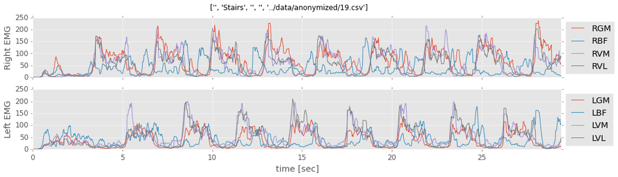

```python
stairs_eg = files[files.Exercise=='Stairs'].groupby('Person_id').first()
my.load_and_plot(stairs_eg[:1])
```

Here's an example of another exercise called "Butt Blaster". Except for the right inner quad muscle, only the muscles of the left leg are active during this exercise.

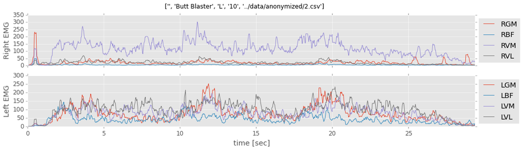

```python
bblaster_eg = files[files.Exercise=='Butt Blaster'].groupby('Person_id').first()
my.load_and_plot(bblaster_eg[:1])
```

As you can see, the "stairs" and "butt blaster" exercises have drastically different EMG signal profiles. We'd like to be able to quantify these differences.

To inspect how these activities differ between individuals, we can save a bunch of plots to disk and flip through them.

```python
# plot all listed files and save as pdfs (without displaying)
my.load_and_plot(stairs_eg, '../data/results/figs/stairs_eg/', plot_on=False)
my.load_and_plot(bblaster_eg, '../data/results/figs/bblaster_eg/', plot_on=False)
```

##### Cleaning

After getting a feel for the data in general, it's a great idea to come up with some simple quality metrics and plot their distributions. This can help identify any obvious issues or errors (i.e. "data smells") that could potentially affect downstream results. In my case, after inspecting the data, not only did I observe some patterns in the data, but I also found some evidence of bad EMG recordings.

Based on some of my observations, I came up with some criteria for discerning 'good' data from potentially 'bad' data, and excluded a portion of the data. Notably, most of the data files I excluded had a large fraction of 0-values for one or more of the EMG leads, which could have been due to a broken lead, or bad contact between the sensor and the user's skin. Other quality metrics I evaluated include:

- number of rows - to find files that are too short or long enough to sample multiple times
- max value across all channels (below 30,000) - magnitude of the signal
- median value across all channels - find files with signals that are too low
- number of spikes to 65535 - files where sensor was freaking out
- max fraction of zero values across channels - possibly dead sensors?
- max fraction of consecutive non-zero values - files with temporal binning issues

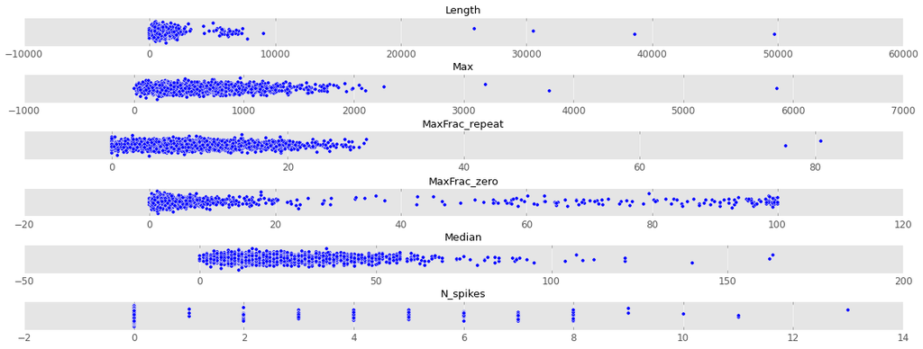

```python
# calculate quality metrics like the fraction of 0-value
files_qc = my.check_quality(files)
files_qc.to_csv('../data/files_qc.csv')
```

Based on this, we can define some exclusion criteria:

- trials must be longer than 500, or ~12.5 sec (not too short)
- the fraction of repeated values must be less than 60% (not too laggy)
- the fraction of zero values must be less than 30% (no dead sensors)
- the median signal value must be less than 100 (not too noisy)

and then apply these criteria to remove "bad" files.

```python
files_precleaned = files.copy() # keep a copy of the uncleaned files to analyze later
files = my.exclude_by_quality(files, files_qc, '../data/dirty/')
```

```
excluded 570 files of 2415
```

Now, let's look at the distribution of exercises:

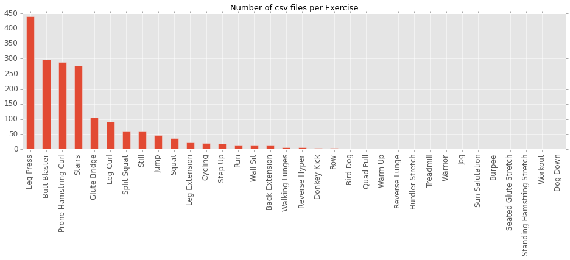

```python
counts = files.Exercise.value_counts()
counts.plot(kind='bar', title='Number of csv files per Exercise');
```

Since there are so many distinct exercises, let's only consider the 5 most frequent. Later, we can try to perform some clustering to identify groups of related exercises, but we'll need to come up with a way to validate those clusters (One idea is to ask a professional trainer to group similar exercises, and then check out those groups compare to automatically-detected clusters).

```python
N = 5
top_N = counts[range(N)].index.tolist()
files = files.query('Exercise == ' + str(top_N))
print 'The top %d exercises, %s, contain %d files.' % (N, top_N, len(files))
```

```
The top 5 exercises, ['Leg Press', 'Butt Blaster', 'Prone Hamstring Curl', 'Stairs', 'Glute Bridge'], contain 1406 files.
```

Finally, let's split the dataset into training and validation (test) sets by person, and sample a 10 second window from the middle of each data file.

```python
# select subsets of the data for model development/testing validation
files_train, files_test = my.split_by_personid(files, 0.8)
print 'Split into %d training files and %d validation files' % (
    len(files_train), len(files_test))
```

```
Split into 1057 training files and 349 validation files
```

```python
# calculate features across files and standardize them
n_sec = 10
feat_train = my.get_features(files_train, n_sec, standardize=True)
feat_test = my.get_features(files_test, n_sec, standardize=True)
```

```python
# save these for easy loading later
feat_train.to_pickle('../data/features_train')
feat_test.to_pickle('../data/features_test')
```

```python
# OPTIONAL: load features from file
feat_train = pandas.read_pickle('../data/features_train')
feat_test = pandas.read_pickle('../data/features_test')
```

## Exploratory analysis

After cleaning the data and inspecting it to get a feel for its properties, one can start to do some exploratory data analysis. This might involve applying transformations to the data, designing features that characterize different aspects of the data, understanding the relationships among those features, and possibly transforming those features or selecting subsets of them to reduce the dimensionality of the feature space.

Feature engineering was a critical component of my project. I knew that I'd have to design some features that:

- summarize arbitrarily long chuncks of sensor data
- are diverse enough to characterize independent aspects of an exercise
- are intuitive and biomechanically relevant

As a start, I designed sets of features that "live" in the EMG-signal domain, the frequency domain, and the time domain.

- The first set (8 features) represent the *intensity of muscle contraction* for the inner and outer quads, hamstrings, and glutes for the right and left legs.  
  Intensities were quantified as the mean peak values for each sensor channel.
- The next set (2 features) represent the *cadence, or tempo* of muscle contraction during the exercise.  
  Cadence was quantified by extracting the two strongest frequency components across all sensor channels.
- The last set (8 features) represent *relative timing* of muscle contraction.  
  Relative timing was quantified as phase lag (derived from the cross-correlation) between pairs of sensor channels.

Here's a nice scatter plot to visualize the relationships between features. The diagonals show a kernel-density estimation plot for each feature.

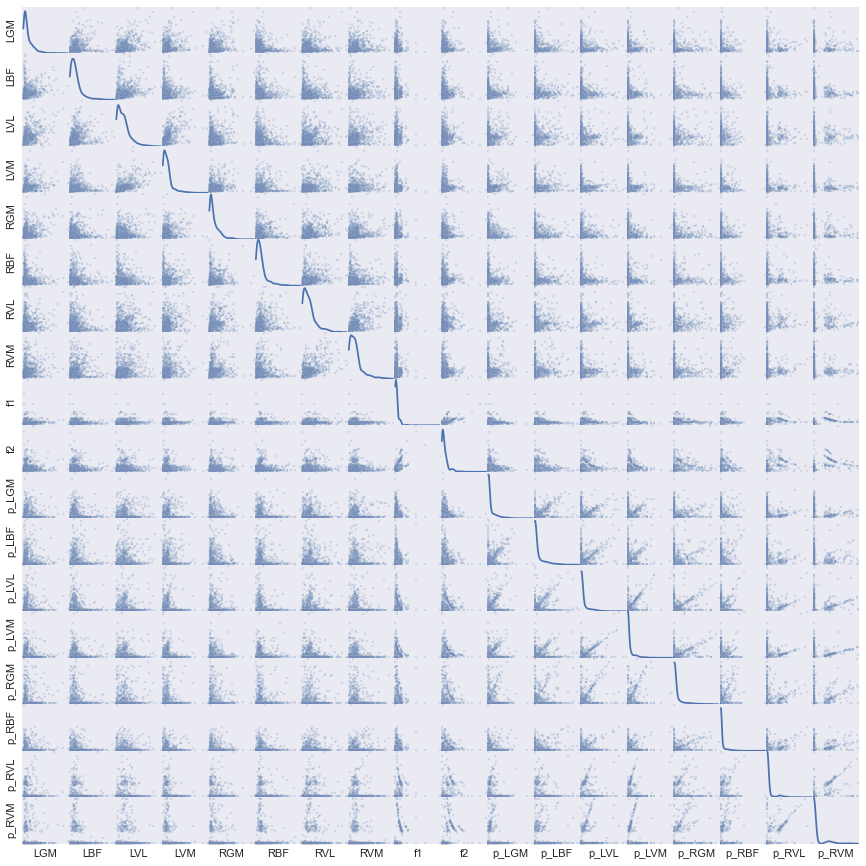

```python
# visualize features in the training or test set
ax = viz.plot_feature_scatter(feat_train, files_train,
                             write_dst='../data/results/figs/features_scatter.pdf')
```

```python
viz.set_styles()  # styles got messed up some how
```

There are some pretty distinct correlations between the inner (VM) and outer (VL) quad muscles of the same leg, as might be expected. Some natural clustering is also apparent in the plots of exercise frequency (f1 and f2) versus phase shift (p_*), most notably, for the inner and outer quad muscles.

Here's another neat visualization that lets us see if there's any natural grouping in the data.

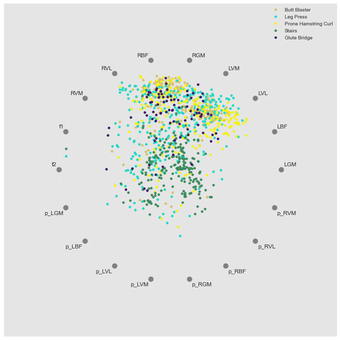

```python
figsize = viz.mpl.rcParams['figure.figsize']
viz.mpl.rc('figure', figsize=[12, 12]) # temporarily change

temp = feat_train.join(files_train.Exercise)

ax = pandas.tools.plotting.radviz(temp, 'Exercise')
ax.set_yticks([])
ax.set_xticks([])
viz.mpl.rc('figure', figsize=figsize) # temporarily change
```

From this visual representation, it appears that the `Stairs` exercise (green) is fairly distinct, `Leg Press` and `Hamstring Curls` examples are fairly distributed across the feature space, while `Butt Blaster` and `Glute Bridge` are more concentrated, but embedded in the region of the feature space that is heavily occupied.

## Model development and testing

Now that we have a reduced set of Exercise labels, clean data, and reasonable features, we can train a few classifiers to distinguish between different exercises.

```python
X_train = feat_train
y_train = files_train.Exercise

X_test = feat_test
y_test = files_test.Exercise
```

```python
y_train = y_train.replace(to_replace='Prone Hamstring Curl', value='Hamstr. Curl'); # shorten for asthetics
y_test = y_test.replace(to_replace='Prone Hamstring Curl', value='Hamstr. Curl'); # shorten for asthetics
```

First, let's try an SVM with a Gaussian kernel. SVMs are binary classifiers by definition, but they can be used in a "one-vs-rest" (or in the case of scikit-learn, "one-vs-one") framework to act as a multi-class classifier.

```python
from sklearn import svm
```

```
percent correct: 81.3753581662
             precision    recall  f1-score   support

Butt Blaster       0.79      0.67      0.72        75
Glute Bridge       0.60      0.50      0.55        18
Hamstr. Curl       0.89      0.97      0.93        78
  Leg Press       0.75      0.79      0.77       116
     Stairs       0.89      0.92      0.90        62

avg / total       0.81      0.81      0.81       349
```

```
81.375358166189116
```

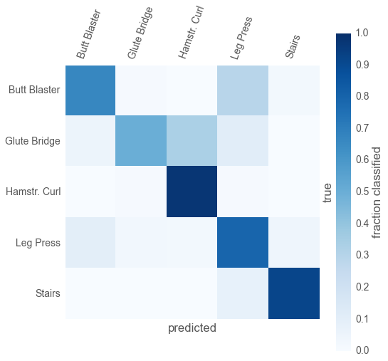

```python
svc = svm.SVC(gamma=0.001, C=100.)
svc.fit(X_train, y_train)

my.prediction_report(svc.predict(X_test), y_test, svc.classes_)
```

Wow, that worked pretty well. When I first got this result I was pleasantly surprised.

But by looking horizontally along rows, it's clear that this classifier is confusing instances of `Butt Blaster` with `Leg Press`, and `Glute Bridge` with `Hamstring Curl`. As we showed earlier, in this particlar dataset, `Leg Press` is over-represented while `Glute Bridge` was under-represented, so this result makes sense. If trained on unbalanced labels, a classifier will more often predict the classes that are over-represented.

To account for unbalanced classes, we can apply some sort of weighting scheme. This is easy to do in scikit-learn using the `class_weights` parameter, which scales the each class's C-parameter by the inverse frequency of that class.

```
percent correct: 76.5042979943
             precision    recall  f1-score   support

Butt Blaster       0.64      0.87      0.73        75
Glute Bridge       0.41      0.78      0.54        18
Hamstr. Curl       0.89      0.97      0.93        78
  Leg Press       0.84      0.47      0.60       116
     Stairs       0.91      0.94      0.92        62

avg / total       0.80      0.77      0.76       349
```

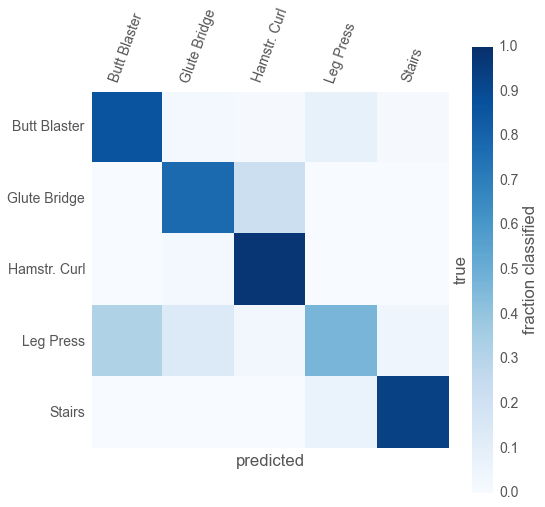

```python
# class_weight='auto' accounts for unbalanced classes
svc = svm.SVC(gamma=0.001, C=100., class_weight='auto')
svc.fit(X_train, y_train)

my.prediction_report(svc.predict(X_test), y_test, svc.classes_);
```

By accounting for unbalanced classes, the overall accuracy was not better, but that's OK. Since we don't expect `Leg Press` (which is over-represented in this dataset) to be performed more often under normal circumstances we shouldn't "cheat" by predicting it more often than we should.

## Optimizing model performance

Great, we've got a model that does a fairly good job of predicting the kind of activity an individual is doing. Now we can try to optimize model performance on the training data using a grid search with a nested 5-fold cross validation. During this process, models are trained on 4/5ths of the training data and evaluated on 1/5th (this is repeated 5 times). Parameters are then chosen based on the average of some performance metric (in our case, 'recall').

This technique is nice because it leaves our test set untouched (which is critical), without requiring us to set aside a separate set of data strictly for parameter tuning.

```python
# following grid search example on sklearn
from sklearn.cross_validation import train_test_split
from sklearn.grid_search import GridSearchCV

tuned_parameters = [{'kernel': ['rbf'], 'gamma': [1, 1e-1, 1e-2, 1e-3], 'class_weight': ['auto'], 'C': [1, 10, 100, 1000, 10000]}]
score = 'recall'

print("# Tuning hyper-parameters for %s" % score)
print

grid = GridSearchCV(svm.SVC(C=1, cache_size=500), tuned_parameters, cv=5, scoring=score, n_jobs=-1)
grid.fit(X_train, y_train)

print("Best parameters set found on training set:")
print
print(grid.best_estimator_)
# print
# print("Grid scores on development set:")
# print
# for params, mean_score, scores in grid.grid_scores_:
#     print("%0.3f (+/-%0.03f) for %r"
#           % (mean_score, scores.std() / 2, params))
```

```
# Tuning hyper-parameters for recall

Best parameters set found on training set:

SVC(C=10, cache_size=500, class_weight='auto', coef0=0.0, degree=3, gamma=0.1,
  kernel='rbf', max_iter=-1, probability=False, random_state=None,
  shrinking=True, tol=0.001, verbose=False)
```

```
percent correct: 85.9598853868
             precision    recall  f1-score   support

Butt Blaster       0.89      0.85      0.87        75
Glute Bridge       0.48      0.72      0.58        18
Hamstr. Curl       0.95      0.88      0.91        78
  Leg Press       0.84      0.83      0.83       116
     Stairs       0.92      0.94      0.93        62

avg / total       0.87      0.86      0.86       349
```

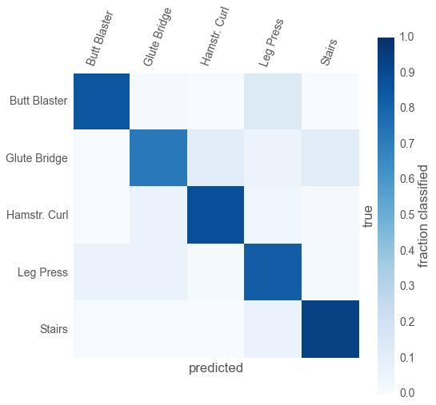

```python
best = grid.best_estimator_
my.prediction_report(best.predict(X_test), y_test, best.classes_); #, print_mat='frac');
```

```python
from sklearn.ensemble import ExtraTreesClassifier
from sklearn.grid_search import RandomizedSearchCV
from scipy.stats import randint
```

We can use a similar approach to tune the parameters of an Extremely Randomized Trees classifier. Here we'll use a random search instead of a grid search...just for the sake of randomness, of course ;-)

```python
clf = ExtraTreesClassifier(n_jobs=-1)
# specify parameters and distributions to sample from
param_dist = {"max_depth": [3, None],
              "n_estimators": randint(500, 2000),
              "max_features": randint(1, 11),
              "min_samples_split": randint(1, 11),
              "min_samples_leaf": randint(1, 11),
              "bootstrap": [True, False],
              "criterion": ["gini", "entropy"]}

# run randomized search
n_iter_search = 20
score = 'recall'
random_search = RandomizedSearchCV(clf,
                                   param_distributions=param_dist,
                                   n_iter=n_iter_search,
                                   scoring=score,
                                   n_jobs=-1)

random_search.fit(X_train, y_train)

print("Best parameters set found on development set:")
print
print(random_search.best_estimator_)
# print
# print("Grid scores on development set:")
# print
# for params, mean_score, scores in random_search.grid_scores_:
#     print("%0.3f (+/-%0.03f) for %r"
#           % (mean_score, scores.std() / 2, params))
```

```
Best parameters set found on development set:

ExtraTreesClassifier(bootstrap=True, compute_importances=None,
           criterion='entropy', max_depth=None, max_features=6,
           max_leaf_nodes=None, min_density=None, min_samples_leaf=1,
           min_samples_split=7, n_estimators=1062, n_jobs=-1,
           oob_score=False, random_state=None, verbose=0)
```

```
percent correct: 88.8252148997
             precision    recall  f1-score   support

Butt Blaster       0.93      0.83      0.87        75
Glute Bridge       0.86      0.33      0.48        18
Hamstr. Curl       0.88      1.00      0.93        78
  Leg Press       0.85      0.89      0.87       116
     Stairs       0.94      0.98      0.96        62

avg / total       0.89      0.89      0.88       349
```

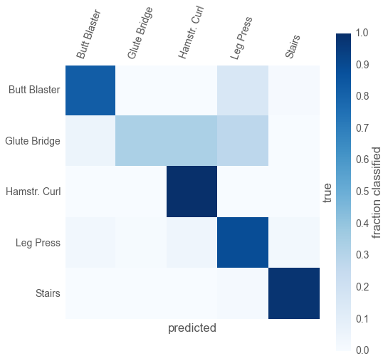

```python
best = random_search.best_estimator_
my.prediction_report(best.predict(X_test), y_test, best.classes_);
```

One nice aspect of Tree Ensembles like Random Forests and Extra Trees is that (at least in scikit-learn) it's straightforward to compute feature importances. The basic idea is to scramble each feature column and then measure the decrease in model performance.

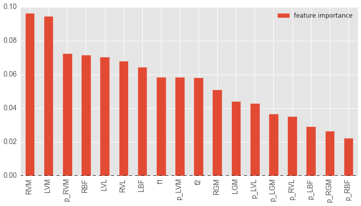

```python
importance = random_search.best_estimator_.feature_importances_
ix = importance.argsort()
index = feat_test.columns.values
df_importance = pandas.DataFrame({'feature importance':importance}, index=index).sort(['feature importance'], ascending=False)
df_importance.plot(kind='bar', figsize=(12, 6));
```

We could have also done something similar for our SVM using [Recursive Feature Elimination](http://scikit-learn.org/stable/auto_examples/plot_rfe_digits.html#example-plot-rfe-digits-py)

## Next steps and future work

OK, in this post we've gone through the whole pipeline of a prototypical data science project, from data cleaning to validation of a predictive model--but there's always more work to be done! Below are some further questions and potential areas of improvement.

- Did cleaning the data improve the results? How do we automate or fix this for future datasets?
- Could accelerometer data improve activity classification? By how much?
- How can activity classification benefit users? What other DataSci techniques could provide value?
- How much does prediction accuracy go down with an increasing number of activties (which also have less exemplars).
- Should unilateral exercises performed by the Left and Right legs be classified separately?
- Can one use a hierchical clustering method to identify groups of similar exercises, and make predictions within those known (or assumed) clusters?
- Can predictions be made based on time-series data (e.g. using a Hidden Markolf Model or Recurrent Neural Net) instead of based on 10-second time intervals?
- To what extent dos the length of time windows affect prediction accuracy?

```python
HTML('athospy/marks_style.html')
```